# Homework 4

Davide Berasi

2023-07-05

# Exercise 2: Mixture of binomials

In the below table there are $40$ observations $y_i \sim Bin(m_i, p_i)$. Data are also available in the file homework-bs-4-1.Rdata

| m | 28 | 35 | 20 | 35 | 32 | 25 | 33 | 38 | 39 | 34 | 28 | 37 | 27 | 27 | 26 | 31 | 23 | 39 | 28 | 33 | 32 | 31 | 31 | 32 | 28 | 38 | 38 | 24 | 29 | … |
| --- | --- | --- | --- | --- | --- | --- | --- | --- | --- | --- | --- | --- | --- | --- | --- | --- | --- | --- | --- | --- | --- | --- | --- | --- | --- | --- | --- | --- | --- | --- |
| y | 8 | 33 | 7 | 11 | 11 | 2 | 30 | 36 | 10 | 11 | 8 | 3 | 24 | 6 | 5 | 26 | 1 | 35 | 27 | 32 | 6 | 26 | 25 | 0 | 2 | 9 | 4 | 8 | 2 | … |

> - Assume that the number of distinct $p_i$s is $4$. Implement in R a Gibbs sampler based on data augmentation following the model discussed in class and available in the notes Ch-MCMC.pdf

In our model we suppose that $p_i \in \{\gamma_1, \dots, \gamma_k\} \subset [0, 1]^k$ where $k$ is the number of components we suppose there exist, in our case we know that $k=4$. We consider the $p_i$ as independent random variables with $\mathbb{P}(p_i = \gamma_j) = \alpha_j$, where $\alpha = (\alpha_1, \dots, \alpha_k) \in \Delta^{k-1}$. In the Bayesian framework $\alpha$ and $\gamma$ are random variables and we assume they are independent. For them we chose the following prior distributions:

$$\gamma_j \stackrel{\text{ind}}{\sim} Beta(a_j, b_j), \hspace{0.5cm} j=1,
\dots, k\\
\alpha \sim Dirichlet(c_1, \dots, c_k)$$
We are interested in the joint posterior distribution $\pi(\alpha, \gamma)=f(\alpha, \gamma \lvert y) \propto f(y \vert \alpha, \gamma) f(\alpha, \gamma)$. This distribution can be written explicitly, but it is not easy to directly sample from it.

To simplify the problem we can use the data augmentation technique, that simply consists in introducing some new variables in such a way that the full conditional distributions can be computed easily.

In our case we define the categorical variable $C_i = j \mbox{ iff } p_i = \gamma_j$. Moreover it is useful to represent this variable also with its “one-hot encoding” $z_{ij}$, that is $z_{ij} = 1$ if $C_i=j$ and 0 otherwise.

Notice that the rows in the matrix $Z = (z_{ij})_{ij}$ are independent and that $\mathbb{P}(z_{ij}=1 \lvert \alpha, \beta)=\alpha_j$. Now we are interested in the joint posterior $\pi(\alpha, \gamma, Z)=f(\alpha, \gamma, Z \lvert y) \propto f(y \vert \alpha, \gamma, Z) f(Z \lvert \alpha, \gamma) f(\alpha, \gamma)$.

It is easy to verify that the full conditional posteriors are:

- $\alpha \lvert (\gamma, Z, y) \sim Dirichlet(c_1+z_{+1}, \, \dots, \, c_k+z_{+k})$ where $z_{+j}=\sum_{i=1}^k z_{ij}$
- $\gamma_j \lvert (\alpha, Z, y) \sim Beta(a_j + y_{+j}, \, b_j + m_{+j}-y_{+j})$ where $y_{+j}=\sum_{i=1}^k z_{ij}y_i$ and $m_{+j}=\sum_{i=1}^k z_{ij}m_i$
- $\mathbb{P}(z_{ij}=1 \lvert \alpha, \beta) \propto \alpha_j \gamma_j^{y_i}(1-\gamma_j)^{m_i-y_i}$

We have everything to implement our Gibbs sampler. In the implementation I prefer to work with the $C_i$ instead of $Z$.

```r
library("LearnBayes")

Gibbs <- function(n.iter, start, params, data, burn.in){
  m <- data$m
  y <- data$y
  k <- params$k
  n <- length(y)

  alpha.seq <- matrix(NA, ncol=k, nrow=n.iter)
  gamma.seq <- matrix(NA, ncol=k, nrow=n.iter)
  C.seq <- matrix(NA, ncol=n, nrow=n.iter)


  C <- C.seq[1,] <- start$C
  alpha <- alpha.seq[1,] <- start$alpha
  gamma <- gamma.seq[1,] <- start$gamma

  for(l in 2:n.iter){
    # alpha | gamma, Z
    z.plus_j <- tabulate(C, nbins = k)
    alpha <- rdirichlet(1, params$c + z.plus_j)

    # gamma | alpha, Z
    y.plus_j <- apply(as.matrix(1:k), 1, function(j) sum(y[C==j]))
    m.plus_j <- apply(as.matrix(1:k), 1, function(j) sum(m[C==j]))
    gamma <- rbeta(k, params$a + y.plus_j, params$b + m.plus_j - y.plus_j)
    gamma <- sort(gamma) # To avoid label switching

    # C | alpha, gamma
    for (i in 1:n){
      prob <- alpha * gamma^y[i] * (1 - gamma)^(m[i]-y[i])
      prob <- prob / sum(prob)
      C[i] <- sample(1:k, 1, prob=prob)
    }

    alpha.seq[l,] <- alpha
    gamma.seq[l,] <- gamma
    C.seq[l,] <- C
  }
  result <- list(alpha = alpha.seq[-(1:burn.in),],
                 gamma = gamma.seq[-(1:burn.in),],
                 C = C.seq[-(1:burn.in),])
  return(result)
}
```

> - Run the Gibbs sampler for the above data and summarize your finding.

As initial state we order the data according to $p=y/m$ and split them in the 4 quarters, for $\alpha$ we take a uniform distribution and for $\gamma$ we take the means of $p$ in the 4 initial components.

As hyperparameters we take $a_j=b_j=c_j=1$ for each $j=1, \dots, k$, so that the prior for $\alpha$ and $\gamma$ are uniform distributions.

With this values we run the chain for 5000 iterations and we discard the first 1000.

```r
k <- 4
p <- y/m
sorted.idx <- order(p)
y <- y[sorted.idx]
m <- m[sorted.idx]
quarters <- rep(1:4, each=10)

start <- list(alpha = rep(1/k, k),
              gamma = apply(as.matrix(1:k), 1, function(j) mean(p[quarters==j])),
              C = quarters)

params <- list(c = rep(1, k),
               a = rep(1, k), b = rep(1, k),
               k = k)

system.time(result <- Gibbs(5000, start, params, data=list(m=m, y=y), burn.in = 1000))
```

```
##    utente   sistema trascorso
##      2.43      0.03      2.69
```

As estimators for $\alpha$ and $\gamma$ we take the the median of the corresponding posterior, for $C_i$ is the closest integer to the median of the posterior.

It is interesting to see the values of our estimates for $\gamma$ and for the number of observations belonging to each cluster.

```r
C <- apply(result$C, 2, median)
gamma <- apply(result$gamma, 2, median)
alpha <- apply(result$alpha, 2, median)
N_j <- tabulate(C, nbins = k) # N_J[j] is the number of observations in cluster j. It is equal to z.plus_j
rbind(N_j, gamma)
```

```
##             [,1]       [,2]      [,3]       [,4]
## N_j   9.00000000 13.0000000 6.0000000 12.0000000
## gamma 0.08401411  0.2319378 0.3021896  0.9051009
```

We actually know the true value of $\gamma$, and we can see that the distance of our estimate from it is small.

```r
norm(gamma - sort(theta), "2")
```

```
## [1] 0.05693379
```

It is interesting to compare the density of $y_i / m_i$ with the densities of the 4 components. We can notice that 3 of the clusters are close and they overlap.

```r
# Helper function to plot the density of each component.
plot.clusters.densities <- function(y, C, alpha){
  k <- length(alpha)
  bw <- bw.nrd0(y)

  plot(density(y, bw=bw), lwd=4, col="gray", main = "Density of the components" )
  points(cbind(y,0), col=C)
  for (j in 1:k) {
    if (sum(C==j) > 0){
      d <- density(y[C==j], bw=bw)
      d$y <- d$y * alpha[j]
      lines(d, col=j, lwd=2)
    }
  }
}
```

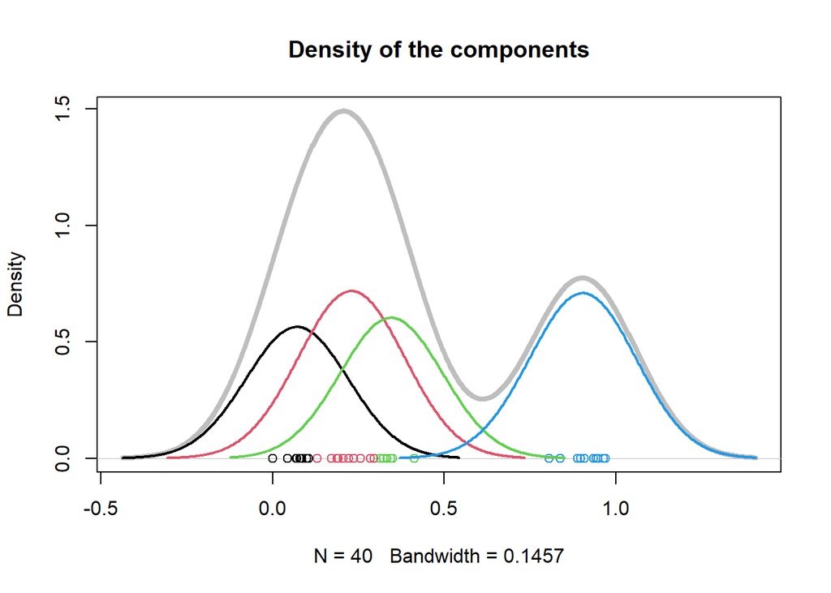

```r
plot.clusters.densities(y/m, C, alpha)
```

> - Use JAGS to implement the same model and compare the results

We define the model in BUGS syntax

```r
library(R2jags)
mixture <- "model {
  a <- c(1,1,1,1)
  b <- c(1,1,1,1)
  c <- c(1,1,1,1)

  # Likelihood
  for (i in 1:N) {
    y[i] ~ dbin(p[i], m[i])
    p[i] <- gamma[C[i]]
    C[i] ~ dcat(alpha[1:k])
  }

  # Priors
  alpha ~ ddirch(c[1:k])
  for (j in 1:k) {
    gamma_aux[j] ~ dbeta(a[j], b[j])
  }
  gamma[1:k] <- sort(gamma_aux[1:k])
}"
```

and we run the chain for 5000 iterations.

```r
data <- list(y=y, m=m, N=40, k=k)
parameters <- c("alpha", "gamma", "C")

mixturerun <- jags(
  data = data,
  parameters.to.save = parameters,
  model.file = textConnection(mixture),
  n.chains = 1,
  n.iter = 5000,
  n.burnin = 1000
)
```

```
## module glm loaded
```

The results are quite similar to what we obtained with our Gibbs sampler.

```r
C <- round(mixturerun$BUGSoutput$median$C)
alpha <- mixturerun$BUGSoutput$median$alpha
gamma <- mixturerun$BUGSoutput$median$gamma

N_j <- tabulate(C, nbins=4)
rbind(N_j, gamma)
```

```
##             [,1]      [,2]       [,3]       [,4]
## N_j   9.00000000 9.0000000 10.0000000 12.0000000
## gamma 0.08363648 0.2350055  0.2959505  0.9048819
```

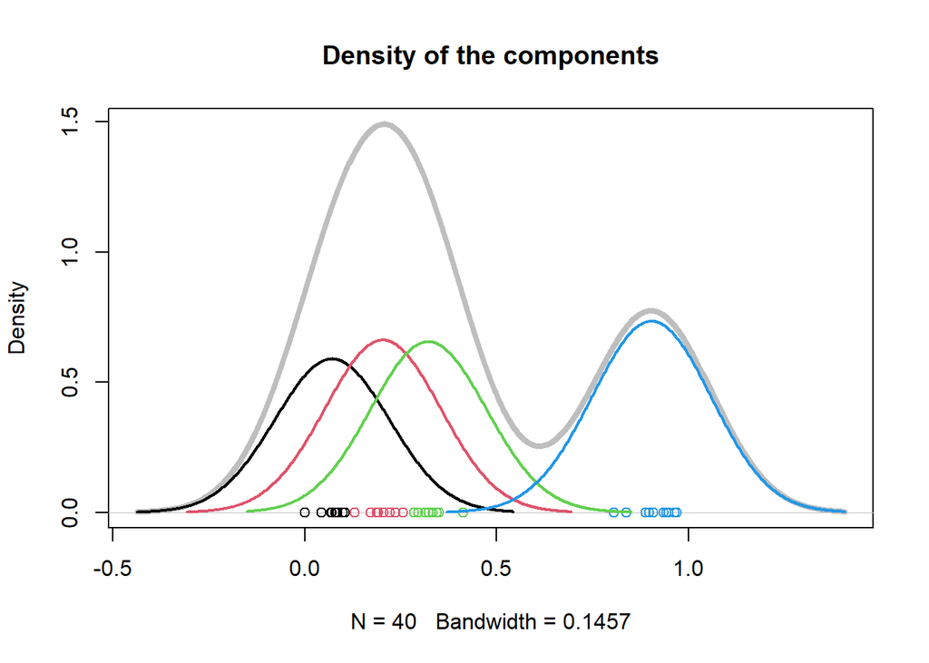

```r
plot.clusters.densities(y/m, C, alpha)
```

> - Assume now the number of components (distinct $p_i$) is unknown. Implement in R a non parametric Gibbs sampler with stick-breaking approach and Dirichlet prior

In the non-parametric setup our model is:

$$y_i \, \lvert \, C_i, \gamma \sim Bin(m_i, p_{C_i}) \\
C_i \, \lvert \, \pi \sim \pi, \ \ \pi \sim GEM(\beta) \\
p_j \sim Beta(a, b)$$

```r
Gibbs.non_param <- function(n.iter, start, params, data, burn.in){
  m <- data$m
  y <- data$y
  n <- length(y)
  k <- params$k  # Maximum number of clusters

  C.seq <- matrix(NA, ncol=n, nrow=n.iter)
  p.seq <- matrix(NA, ncol=k, nrow=n.iter)
  N_j.seq <- matrix(NA, ncol=k, nrow=n.iter)
  PI.seq <- matrix(NA, ncol=k, nrow=n.iter)

  C <- C.seq[1,] <- start$C
  p <- p.seq[1,] <- start$p
  PI <- PI.seq[1,] <- start$PI
  N_j <- N_j.seq[1,] <- tabulate(C, nbins = k)

  for(l in 2:n.iter){
    # p_i | Z_i, y_i
    y.plus_j <- apply(as.matrix(1:k), 1, function(j) sum(y[C==j]))
    m.plus_j <- apply(as.matrix(1:k), 1, function(j) sum(m[C==j]))
    p <- rbeta(k, params$a + y.plus_j, params$b + m.plus_j-y.plus_j)

    # PI | Z_i
    stick.length <- 1
    for (j in 1:(k-1)){
      PI[j] <- stick.length * rbeta(1, params$alpha + N_j[j], params$beta + sum(N_j[(j+1):k]))
      stick.length <- stick.length - PI[j]
    }
    PI[k] <- 1 - sum(PI[1:(k-1)])

    # Z_i | p_i, PI
    for (i in 1:n){
      prob <- PI * dbinom(y[i], m[i], prob=p)
      C[i] <- sample(1:k, 1, prob = prob)
    }
    # Update N_j
    N_j <- tabulate(C, nbins = k)

    C.seq[l,] <- C
    PI.seq[l,] <- PI
    p.seq[l,] <- p
    N_j.seq[l,] <- N_j
  }

  result <- list(p = p.seq[-(1:burn.in),],
                 C = C.seq[-(1:burn.in),],
                 N_j = N_j.seq[-(1:burn.in),],
                 PI = PI.seq[-(1:burn.in),])
  return(result)
}
```

> - Run the non parametric Gibbs sampler for the above data and summarize your finding. In particular discuss the posterior distribution of the number of clusters

Now we run the algorithm and we study the number of clusters.

```r
k <- 20
p <- y/m
sorted.idx <- sort.int(p, index.return = TRUE)$ix
y <- y[sorted.idx]
m <- m[sorted.idx]
components <- rep(1:k, each=2)

start <- list(PI = rep(1/k, k),
              p = apply(as.matrix(1:k), 1, function(j) mean(p[components==j])),
              C = components)

params <- list(a = 1, b = 1,
               alpha = 1, beta = 1,
               k = k)

system.time(result <- Gibbs.non_param(5000, start, params, data=list(m=m, y=y), burn.in = 1000))
```

```
##    utente   sistema trascorso
##      4.00      0.00      4.42
```

We can notice that,on average the $\pi_j$ are close to 0 for $j>5$. This indicates that probably there are no more than 5 components.

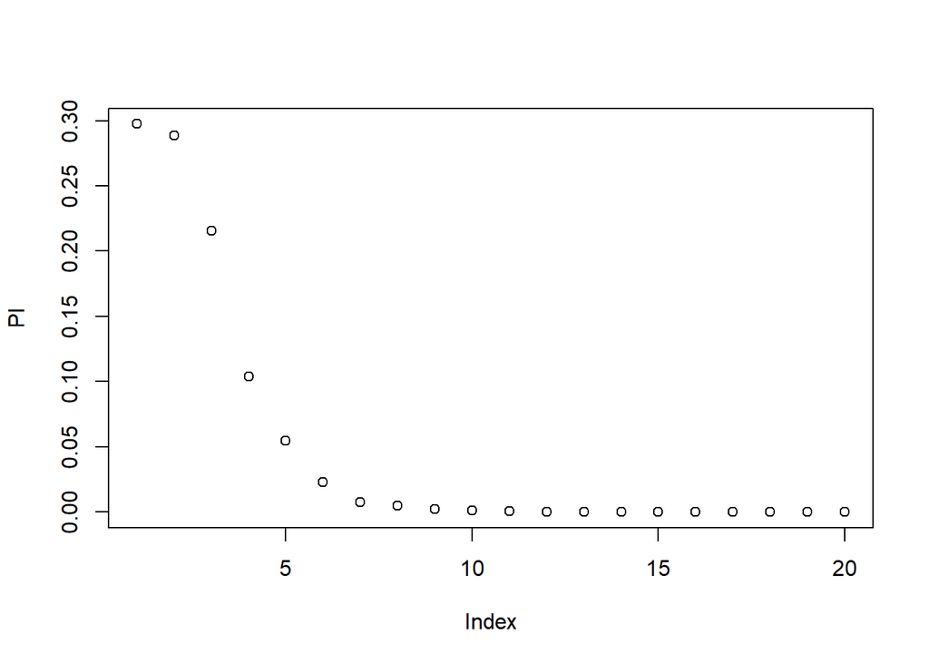

```r
PI <- colMeans(result$PI)
N_j <- tabulate(C, k)

plot(PI)
```

To confirm that, we can look also at the distribution of the number of clusters.

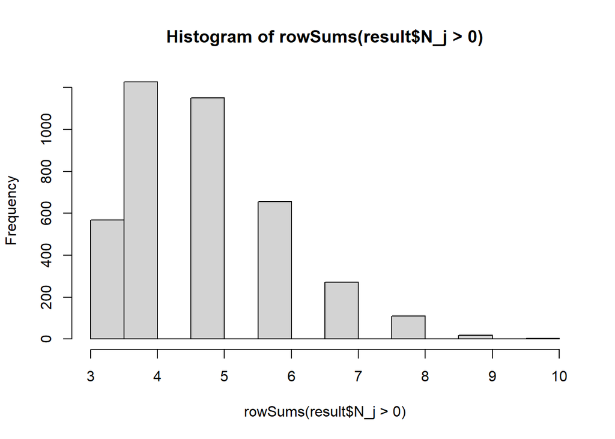

```r
hist(rowSums(result$N_j>0))
```

We can notice that a lot of the cluster we are considering have few components.

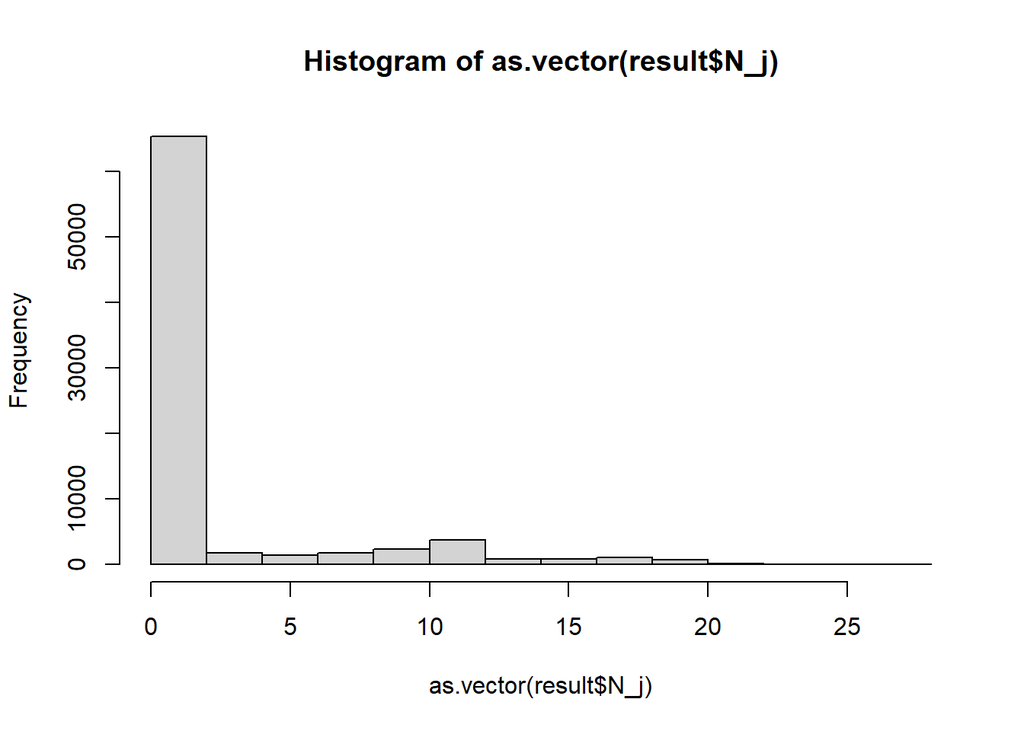

```r
hist(as.vector(result$N_j))
```

So, it makes more sense to not consider the clusters with a small number of elements. In this case it is even more evident that the number of components should be 4.

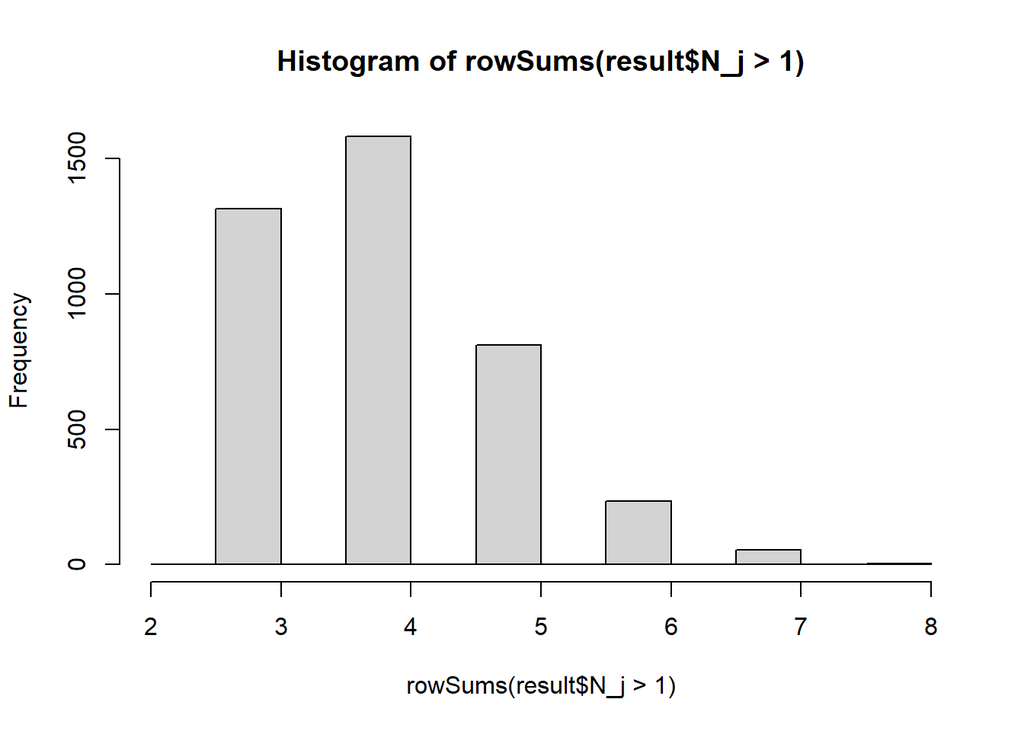

```r
hist(rowSums(result$N_j>1))
```

# Exercise 1: Mixture of Gaussians

In the file homework-bs-4-2.Rdata there are measurements from a Gaussian mixture where each of the component of the mixture is a univariate normal distribution with unknown mean and variance

> - By graphical inspection guess the number of components and implement in R a Gibbs sampler based on data augmentation following the model discussed in the notes Ch-MCMC.pdf

From the plot of the histogram it look like the data comes from 3 different groups.

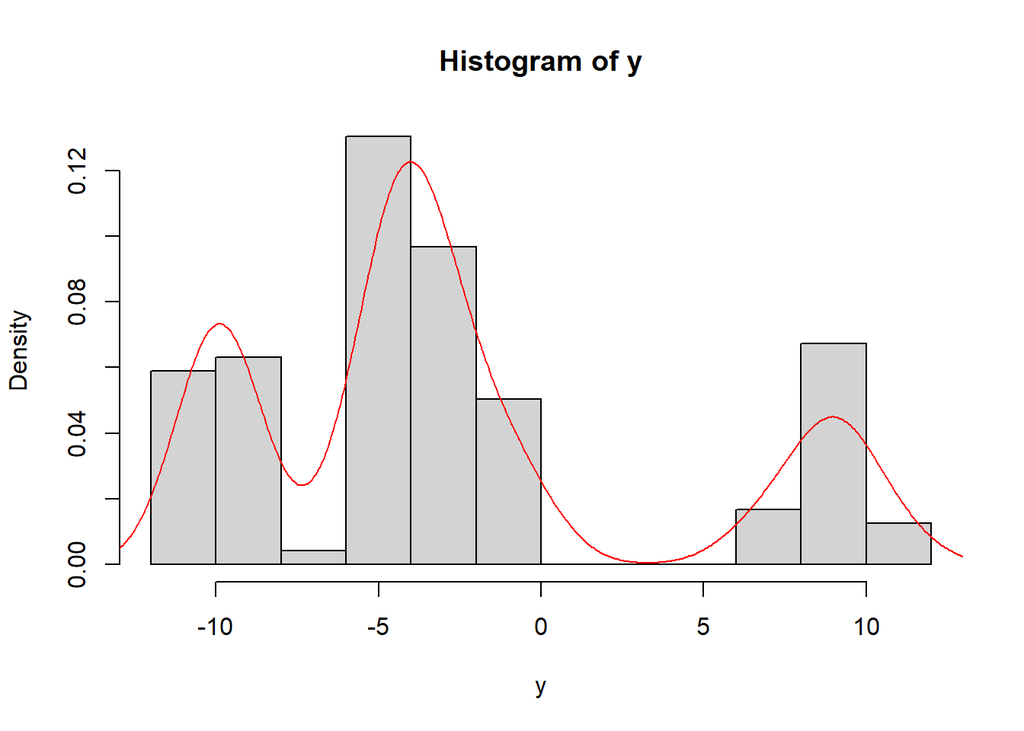

```r
hist(y, freq = FALSE)
lines(density(y), col="red")
```

We have $n = 119$ observations and we model them as a mixture of $k=3$ gaussian. As in the previous exercise, we consider the categorical variables $C_i$ (and their one-hot encoding representation $Z$) that tells us the component of observation $i$, that is $C_i = j$ iff observation $i$ belongs to component $j$.

To construct the model I also followed [this notes](https://web.uniroma1.it/memotef/sites/default/files/file%20lezioni/Lezione3_CMollica.pdf).

Defined $\mu = (\mu_1, \, \dots, \, \mu_k)$ and $\tau = (\tau_1, \, \dots, \, \tau_k)$, our model is:

$$y_i \, \lvert \, (C_i, \, \mu, \, \tau^2) \sim \mathcal{N}(\mu_{C_i}, \,
\tau_{C_i}^{-2}), \hspace{0.5cm} i=1, \dots,n \\
C_i \, \lvert \, \alpha \sim Cat(\alpha), \hspace{0.5cm} i=1, \dots,n \\$$
with prior distributions

$$\alpha \sim Dirichlet(c), \hspace{0.5cm} c=(c_1, \, \dots, \, c_k)\\
\mu_j \, \stackrel{\text{ind}}{\sim} \, \mathcal{N}(\mu_0, \tau_0^{-2}),
\hspace{0.5cm} j=1, \dots,k \\
\tau_j \stackrel{\text{ind}}{\sim} Gamma(a, b), \hspace{0.5cm} j=1,
\dots,k$$

where $a, b, c, \mu_0, \tau_0$ are fixed hyperparameters.

We are interested in the joint posterior distribution $\pi(\alpha, \mu, \tau, Z)$. It can be written explicitly and from it we obtain the full conditional distributions.

- $\alpha \lvert (\mu, \tau, Z) \sim Dirichlet(c_1+z_{+1}, \, \dots, \, c_k+z_{+k})$
- $\mu_j \, \lvert \, (\alpha, \tau, Z) \sim \mathcal{N}\left(\delta_j \frac{y_{+j}}{z_{+j}} + (1-\delta_j) \mu_0, \ (\tau_0+z_{+j}\tau_j)^{-2}\right)$
- $\tau_j \, \lvert \, (\alpha, \mu, Z) \sim Gamma(a + z_{+j}/2, b + SS_j/2)$
- $\mathbb{P}(z_{ij}=1 \lvert \alpha, \mu, \tau) \propto \alpha_j \, \mathcal{N}(y_i | \mu_j, \tau_j^{-2})$

where
$$SS_j = \sum_{i=1}^nz_{ij}(y_i - \mu_j)^2
\hspace{1cm}
\delta_j = \frac{z_{+j} \tau_j}{\tau_0 + z_{+j} \tau_j}$$

We have everything to implement our Gibbs sampler.

```r
Gibbs2 <- function(n.iter, start, params, data, burn.in){
  y <- data
  k <- params$k
  n <- length(y)

  alpha.seq <- matrix(NA, ncol=k, nrow=n.iter)
  mu.seq <- matrix(NA, ncol=k, nrow=n.iter)
  A.seq <- matrix(NA, ncol=k, nrow=n.iter)
  C.seq <- matrix(NA, ncol=n, nrow=n.iter)

  alpha <- alpha.seq[1,] <- start$alpha
  mu <- mu.seq[1,] <- start$mu
  A <- A.seq[1,] <- 1 / start$A # It is tau
  C <- C.seq[1,] <- start$C

  for(l in 2:n.iter){
    # alpha | mu, A, Z
    z.plus_j <- tabulate(C, nbins = k)
    alpha <- rdirichlet(1, params$c + z.plus_j)

    # A | alpha, mu, Z
    SS_j <- apply(as.matrix(1:k), 1, function(j) sum( ((y - mu[j])^2)[C==j]) )
    A <- rgamma(k, shape=params$a + z.plus_j/2,
                   rate=params$b + SS_j/2)

    # mu | alpha, A, Z
    y.plus_j <- apply(as.matrix(1:k), 1, function(j) sum(y[C==j]))
    mean.plus_j <- y.plus_j / z.plus_j
    mean.plus_j[y.plus_j==0] <- 0
    delta_j <- z.plus_j * A / (params$tau0 + z.plus_j*A)

    mu <- rnorm(k,
                mean = delta_j * mean.plus_j + (1 - delta_j) * params$mu0,
                sd = sqrt(1 / (A * z.plus_j + params$tau0)))
    mu <- sort(mu) # Avoid label switching

    # Z | alpha, mu, A
    for (i in 1:n){
      prob <- alpha * dnorm(y[i], mu, sqrt(1/A))
      prob <- prob / sum(prob)
      C[i] <- sample(1:k, 1, prob = prob)
    }

    alpha.seq[l,] <- alpha
    mu.seq[l,] <- mu
    A.seq[l,] <- A
    C.seq[l,] <- C

  }
  result <- list(alpha = alpha.seq[-(1:burn.in),],
                 mu = mu.seq[-(1:burn.in),],
                 A = A.seq[-(1:burn.in),],
                 C = C.seq[-(1:burn.in),])
  return( result )
}
```

> - Run the Gibbs sampler for the above data and summarize your finding

```r
k <- 3
y <- sort(y)
thirds <- rep(1:k, each=length(y)/k+1)[1:length(y)]
start <- list(alpha = rep(1/k, k),
              mu = apply(as.matrix(1:k), 1, function(j) mean(y[thirds==j])),
              A = 1 / apply(as.matrix(1:k), 1, function(j) var(y[thirds==j])),
              C = thirds)

params <- list(c = rep(1, k),
              mu0 = mean(y),
              tau0 = 0.01,
              a = 1, b = 1,
              k=k)
system.time(result <- Gibbs2(5000, start, params, y, burn.in=1000))
```

```
##    utente   sistema trascorso
##      7.02      0.00      8.02
```

As before, for each component we can estimate $\mu_j$, $\sigma_j^2 = \tau_j^{-2}$ and the number of points in each cluster.

```r
C <- apply(result$C, 2, median)
mu <- apply(result$mu, 2, median)
sigma2 <- 1 / apply(result$A, 2, median)
alpha <- apply(result$alpha, 2, median)

N_j <- tabulate(C, nbins = k)
rbind(mu, sigma2, N_j)
```

```
##             [,1]      [,2]      [,3]
## mu     -9.888677 -3.534692  8.829074
## sigma2  0.254888  2.112397  1.531611
## N_j    29.000000 67.000000 23.000000
```

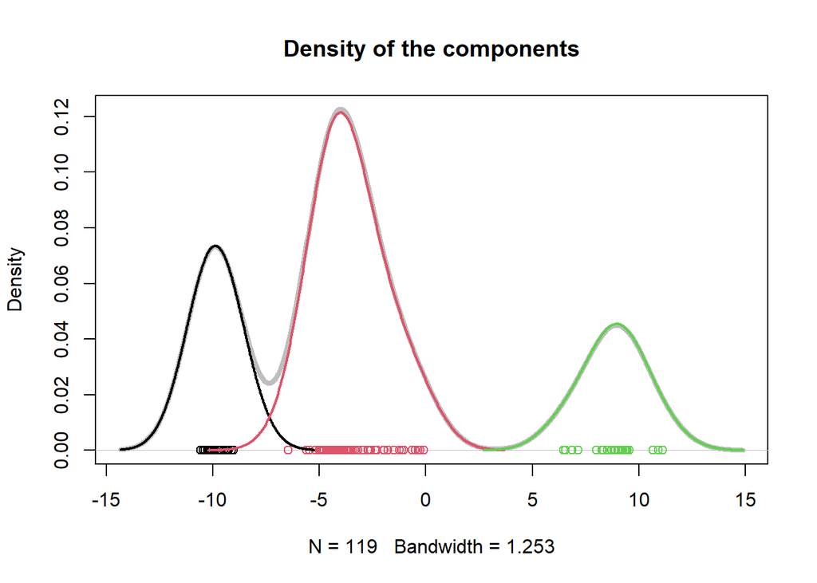

```r
plot.clusters.densities(y, C, alpha)
```

> - Use JAGS to implement the same model and compare the results